# Arm 1: LLM Sensitivity

Fix the embedding model (node: `embed_ads`) and reranker (node: `rerank_candidates`), vary the LLM used in the filter step (node: `llm_filter_candidates`).

The cosine candidates (node: `cosine_candidates`) are identical across all runs with the same embedding, so all disagreement enters at the LLM filter stage. We measure agreement at the filter stage, then track how it propagates through reranking and into the final exposure scores.

## Setup

```
Run definition: validation_5k
Completed runs: 46
```

### Models used

All model keys appearing in the completed runs, with their short display names and full HuggingFace identifiers.

```
LLMs:
```

|  | key | model | hf_name |
| --- | --- | --- | --- |
| 0 | exaone-32b-sbatch | EXAONE-4.0-32B | LGAI-EXAONE/EXAONE-4.0-32B |
| 1 | gemma-27b-sbatch | gemma-3-27b-it | google/gemma-3-27b-it |
| 2 | gpt-oss-120b-sbatch | gpt-oss-120b | openai/gpt-oss-120b |
| 3 | llama-4-scout-sbatch | Llama-4-Scout-17B-16E-Instruct | meta-llama/Llama-4-Scout-17B-16E-Instruct |
| 4 | llama-70b-sbatch | Meta-Llama-3.1-70B-Instruct | meta-llama/Meta-Llama-3.1-70B-Instruct |
| 5 | mistral-large-2-sbatch | Mistral-Large-Instruct-2411 | mistralai/Mistral-Large-Instruct-2411 |
| 6 | phi-4-sbatch | phi-4 | microsoft/phi-4 |
| 7 | qwen-14b-sbatch | Qwen2.5-14B-Instruct | Qwen/Qwen2.5-14B-Instruct |
| 8 | qwen-32b-sbatch | Qwen2.5-32B-Instruct | Qwen/Qwen2.5-32B-Instruct |
| 9 | qwen-72b-sbatch | Qwen2.5-72B-Instruct | Qwen/Qwen2.5-72B-Instruct |
| 10 | qwen-7b-sbatch | Qwen2.5-7B-Instruct | Qwen/Qwen2.5-7B-Instruct |
| 11 | qwen3-8b-sbatch | Qwen3-8B | Qwen/Qwen3-8B |

```
Embeddings:
```

|  | key | model | hf_name |
| --- | --- | --- | --- |
| 0 | bge-large-sbatch | bge-large-en-v1.5 | BAAI/bge-large-en-v1.5 |
| 1 | e5-large-sbatch | e5-large-v2 | intfloat/e5-large-v2 |
| 2 | embedding-gemma-sbatch | EmbeddingGemma-300M | google/EmbeddingGemma-300M |
| 3 | gte-large-sbatch | gte-large-en-v1.5 | Alibaba-NLP/gte-large-en-v1.5 |
| 4 | nomic-embed-sbatch | nomic-embed-text-v1.5 | nomic-ai/nomic-embed-text-v1.5 |
| 5 | qwen3-embed-0.6b-sbatch | Qwen3-Embedding-0.6B | Qwen/Qwen3-Embedding-0.6B |
| 6 | qwen3-embed-8b-sbatch | Qwen3-Embedding-8B | Qwen/Qwen3-Embedding-8B |

```
Rerankers:
```

|  | key | model | hf_name |
| --- | --- | --- | --- |
| 0 | bge-reranker-v2-m3-sbatch | bge-reranker-v2-m3 | BAAI/bge-reranker-v2-m3 |
| 1 | gte-reranker-modernbert-sbatch | gte-reranker-modernbert-base | Alibaba-NLP/gte-reranker-modernbert-base |
| 2 | nemotron-rerank-1b-sbatch | llama-nemotron-rerank-1b-v2 | nvidia/llama-nemotron-rerank-1b-v2 |
| 3 | qwen3-reranker-8b-sbatch | Qwen3-Reranker-8B | Qwen/Qwen3-Reranker-8B |

## Load data

For each (embedding, reranker) pair, collect all LLM runs and load their filter outputs: the set of kept candidates per ad, match counts, and top-1.

```
Arm 1: 4 (embedding, reranker) groups loaded
  bge-large-en-v1.5 + Qwen3-Reranker-8B: 12 LLMs, 4907 common ads
  bge-large-en-v1.5 + gte-reranker-modernbert-base: 2 LLMs, 5000 common ads
  e5-large-v2 + Qwen3-Reranker-8B: 12 LLMs, 4936 common ads
  e5-large-v2 + gte-reranker-modernbert-base: 2 LLMs, 5000 common ads
```

## Filter stage

### Filter selectivity

Each LLM receives 20 cosine candidates per ad and decides which to keep. This table shows how many candidates each LLM retains on average. A selective model (mean ~3) keeps only the strongest matches; a permissive model (mean ~8) keeps most candidates. Selectivity directly affects Jaccard: if one model keeps 3 candidates and another keeps 8, even with full overlap on the 3 the Jaccard is only 3/8 = 0.375.

| group llm | bge-large-en-v1.5 + Qwen3-Reranker-8B mean_candidates | bge-large-en-v1.5 + Qwen3-Reranker-8B median_candidates | bge-large-en-v1.5 + gte-reranker-modernbert-base mean_candidates | bge-large-en-v1.5 + gte-reranker-modernbert-base median_candidates | e5-large-v2 + Qwen3-Reranker-8B mean_candidates | e5-large-v2 + Qwen3-Reranker-8B median_candidates | e5-large-v2 + gte-reranker-modernbert-base mean_candidates | e5-large-v2 + gte-reranker-modernbert-base median_candidates |
| --- | --- | --- | --- | --- | --- | --- | --- | --- |
| EXAONE-4.0-32B | 8.0 | 7.0 | NaN | NaN | 8.2 | 7.0 | NaN | NaN |
| Llama-4-Scout-17B-16E-Instruct | 5.5 | 5.0 | NaN | NaN | 5.4 | 5.0 | NaN | NaN |
| Meta-Llama-3.1-70B-Instruct | 6.3 | 6.0 | 6.3 | 6.0 | 6.4 | 6.0 | 6.4 | 6.0 |
| Mistral-Large-Instruct-2411 | 7.1 | 7.0 | NaN | NaN | 7.3 | 7.0 | NaN | NaN |
| Qwen2.5-14B-Instruct | 4.0 | 3.0 | NaN | NaN | 4.0 | 3.0 | NaN | NaN |
| Qwen2.5-32B-Instruct | 3.6 | 3.0 | NaN | NaN | 3.8 | 4.0 | NaN | NaN |
| Qwen2.5-72B-Instruct | 7.0 | 6.0 | NaN | NaN | 7.1 | 6.0 | NaN | NaN |
| Qwen2.5-7B-Instruct | 5.9 | 5.0 | NaN | NaN | 6.1 | 5.0 | NaN | NaN |
| Qwen3-8B | 2.6 | 3.0 | NaN | NaN | 2.7 | 3.0 | NaN | NaN |
| gemma-3-27b-it | 6.1 | 6.0 | NaN | NaN | 6.4 | 6.0 | NaN | NaN |
| gpt-oss-120b | 3.7 | 3.0 | NaN | NaN | 3.8 | 3.0 | NaN | NaN |
| phi-4 | 4.3 | 4.0 | 4.3 | 4.0 | 4.4 | 4.0 | 4.4 | 4.0 |

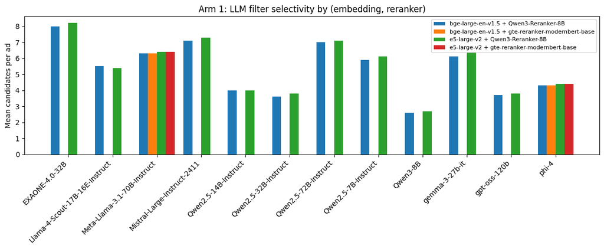

### Pairwise Jaccard (LLM filter kept sets)

For each ad, two LLMs each produce a set of kept O*NET candidates. The Jaccard similarity for that ad is $|A \cap B| \,/\, |A \cup B|$. We average this across all common ads to get the pairwise Jaccard between two LLMs.

A Jaccard of 0.5 means that on a typical ad, the two models share half their candidates. A Jaccard of 1.0 means they keep exactly the same set. Note that Jaccard is sensitive to set size differences (see selectivity above).

| embedding | reranker | mean | median | min | max | std |
| --- | --- | --- | --- | --- | --- | --- |
| bge-large-en-v1.5 | Qwen3-Reranker-8B | 0.442726 | 0.450454 | 0.229093 | 0.590239 | 0.079823 |
|  | gte-reranker-modernbert-base | 0.506900 | 0.506900 | 0.506900 | 0.506900 | 0.000000 |
| e5-large-v2 | Qwen3-Reranker-8B | 0.446974 | 0.450286 | 0.230225 | 0.591652 | 0.081445 |
|  | gte-reranker-modernbert-base | 0.508315 | 0.508315 | 0.508315 | 0.508315 | 0.000000 |

**Jaccard matrix (bge-large-en-v1.5 + Qwen3-Reranker-8B)**

|  | EXAONE-4.0-32B | gemma-3-27b-it | gpt-oss-120b | Llama-4-Scout-17B-16E-Instruct | Meta-Llama-3.1-70B-Instruct | Mistral-Large-Instruct-2411 | phi-4 | Qwen2.5-14B-Instruct | Qwen2.5-32B-Instruct | Qwen2.5-72B-Instruct | Qwen2.5-7B-Instruct | Qwen3-8B |
| --- | --- | --- | --- | --- | --- | --- | --- | --- | --- | --- | --- | --- |
| EXAONE-4.0-32B | 1.000 | 0.542 | 0.405 | 0.467 | 0.536 | 0.549 | 0.451 | 0.421 | 0.429 | 0.536 | 0.387 | 0.272 |
| gemma-3-27b-it | 0.542 | 1.000 | 0.444 | 0.496 | 0.559 | 0.590 | 0.500 | 0.451 | 0.489 | 0.562 | 0.395 | 0.301 |
| gpt-oss-120b | 0.405 | 0.444 | 1.000 | 0.450 | 0.442 | 0.434 | 0.490 | 0.420 | 0.509 | 0.431 | 0.325 | 0.452 |
| Llama-4-Scout-17B-16E-Instruct | 0.467 | 0.496 | 0.450 | 1.000 | 0.502 | 0.481 | 0.493 | 0.436 | 0.501 | 0.471 | 0.377 | 0.333 |
| Meta-Llama-3.1-70B-Instruct | 0.536 | 0.559 | 0.442 | 0.502 | 1.000 | 0.559 | 0.507 | 0.447 | 0.485 | 0.551 | 0.390 | 0.322 |
| Mistral-Large-Instruct-2411 | 0.549 | 0.590 | 0.434 | 0.481 | 0.559 | 1.000 | 0.481 | 0.433 | 0.463 | 0.563 | 0.390 | 0.282 |
| phi-4 | 0.451 | 0.500 | 0.490 | 0.493 | 0.507 | 0.481 | 1.000 | 0.464 | 0.542 | 0.473 | 0.383 | 0.371 |
| Qwen2.5-14B-Instruct | 0.421 | 0.451 | 0.420 | 0.436 | 0.447 | 0.433 | 0.464 | 1.000 | 0.516 | 0.437 | 0.362 | 0.320 |
| Qwen2.5-32B-Instruct | 0.429 | 0.489 | 0.509 | 0.501 | 0.485 | 0.463 | 0.542 | 0.516 | 1.000 | 0.458 | 0.383 | 0.396 |
| Qwen2.5-72B-Instruct | 0.536 | 0.562 | 0.431 | 0.471 | 0.551 | 0.563 | 0.473 | 0.437 | 0.458 | 1.000 | 0.385 | 0.297 |
| Qwen2.5-7B-Instruct | 0.387 | 0.395 | 0.325 | 0.377 | 0.390 | 0.390 | 0.383 | 0.362 | 0.383 | 0.385 | 1.000 | 0.229 |
| Qwen3-8B | 0.272 | 0.301 | 0.452 | 0.333 | 0.322 | 0.282 | 0.371 | 0.320 | 0.396 | 0.297 | 0.229 | 1.000 |

**Jaccard matrix (bge-large-en-v1.5 + gte-reranker-modernbert-base)**

|  | Meta-Llama-3.1-70B-Instruct | phi-4 |
| --- | --- | --- |
| Meta-Llama-3.1-70B-Instruct | 1.000 | 0.507 |
| phi-4 | 0.507 | 1.000 |

**Jaccard matrix (e5-large-v2 + Qwen3-Reranker-8B)**

|  | EXAONE-4.0-32B | gemma-3-27b-it | gpt-oss-120b | Llama-4-Scout-17B-16E-Instruct | Meta-Llama-3.1-70B-Instruct | Mistral-Large-Instruct-2411 | phi-4 | Qwen2.5-14B-Instruct | Qwen2.5-32B-Instruct | Qwen2.5-72B-Instruct | Qwen2.5-7B-Instruct | Qwen3-8B |
| --- | --- | --- | --- | --- | --- | --- | --- | --- | --- | --- | --- | --- |
| EXAONE-4.0-32B | 1.000 | 0.544 | 0.412 | 0.477 | 0.545 | 0.557 | 0.454 | 0.419 | 0.445 | 0.537 | 0.393 | 0.271 |
| gemma-3-27b-it | 0.544 | 1.000 | 0.451 | 0.498 | 0.562 | 0.592 | 0.491 | 0.444 | 0.485 | 0.568 | 0.402 | 0.298 |
| gpt-oss-120b | 0.412 | 0.451 | 1.000 | 0.470 | 0.450 | 0.438 | 0.489 | 0.424 | 0.508 | 0.441 | 0.328 | 0.450 |
| Llama-4-Scout-17B-16E-Instruct | 0.477 | 0.498 | 0.470 | 1.000 | 0.510 | 0.486 | 0.503 | 0.443 | 0.520 | 0.478 | 0.384 | 0.332 |
| Meta-Llama-3.1-70B-Instruct | 0.545 | 0.562 | 0.450 | 0.510 | 1.000 | 0.567 | 0.509 | 0.448 | 0.494 | 0.564 | 0.397 | 0.320 |
| Mistral-Large-Instruct-2411 | 0.557 | 0.592 | 0.438 | 0.486 | 0.567 | 1.000 | 0.479 | 0.426 | 0.471 | 0.574 | 0.397 | 0.282 |
| phi-4 | 0.454 | 0.491 | 0.489 | 0.503 | 0.509 | 0.479 | 1.000 | 0.466 | 0.549 | 0.482 | 0.388 | 0.371 |
| Qwen2.5-14B-Instruct | 0.419 | 0.444 | 0.424 | 0.443 | 0.448 | 0.426 | 0.466 | 1.000 | 0.526 | 0.438 | 0.366 | 0.322 |
| Qwen2.5-32B-Instruct | 0.445 | 0.485 | 0.508 | 0.520 | 0.494 | 0.471 | 0.549 | 0.526 | 1.000 | 0.471 | 0.390 | 0.386 |
| Qwen2.5-72B-Instruct | 0.537 | 0.568 | 0.441 | 0.478 | 0.564 | 0.574 | 0.482 | 0.438 | 0.471 | 1.000 | 0.389 | 0.300 |
| Qwen2.5-7B-Instruct | 0.393 | 0.402 | 0.328 | 0.384 | 0.397 | 0.397 | 0.388 | 0.366 | 0.390 | 0.389 | 1.000 | 0.230 |
| Qwen3-8B | 0.271 | 0.298 | 0.450 | 0.332 | 0.320 | 0.282 | 0.371 | 0.322 | 0.386 | 0.300 | 0.230 | 1.000 |

**Jaccard matrix (e5-large-v2 + gte-reranker-modernbert-base)**

|  | Meta-Llama-3.1-70B-Instruct | phi-4 |
| --- | --- | --- |
| Meta-Llama-3.1-70B-Instruct | 1.000 | 0.508 |
| phi-4 | 0.508 | 1.000 |

### Best subsets by Jaccard

For each subset size k (from all models down to 2), find the subset of k LLMs with the highest mean pairwise Jaccard. This searches all possible combinations exhaustively.

Reading the table from top to bottom shows which models get removed first as k shrinks. If a large subset (say k=8 or k=9) already achieves high agreement, that consensus is evidence of a robust matching. The models removed earliest are the biggest outliers: their filter behaviour diverges most from the group.

|  | embedding | reranker | k | jaccard | subset |
| --- | --- | --- | --- | --- | --- |
| 0 | bge-large-en-v1.5 | Qwen3-Reranker-8B | 12 | 0.443 | all |
| 1 | bge-large-en-v1.5 | Qwen3-Reranker-8B | 11 | 0.466 | all except: Qwen3-8B |
| 2 | bge-large-en-v1.5 | Qwen3-Reranker-8B | 10 | 0.486 | all except: Qwen2.5-7B-Instruct, Qwen3-8B |
| 3 | bge-large-en-v1.5 | Qwen3-Reranker-8B | 9 | 0.496 | all except: Qwen2.5-14B-Instruct, Qwen2.5-7B-I... |
| 4 | bge-large-en-v1.5 | Qwen3-Reranker-8B | 8 | 0.508 | all except: Qwen2.5-14B-Instruct, Qwen2.5-7B-I... |
| 5 | bge-large-en-v1.5 | Qwen3-Reranker-8B | 7 | 0.518 | all except: Qwen2.5-14B-Instruct, Qwen2.5-32B-... |
| 6 | bge-large-en-v1.5 | Qwen3-Reranker-8B | 6 | 0.531 | EXAONE-4.0-32B, gemma-3-27b-it, Llama-4-Scout-... |
| 7 | bge-large-en-v1.5 | Qwen3-Reranker-8B | 5 | 0.555 | EXAONE-4.0-32B, gemma-3-27b-it, Meta-Llama-3.1... |
| 8 | bge-large-en-v1.5 | Qwen3-Reranker-8B | 4 | 0.564 | gemma-3-27b-it, Meta-Llama-3.1-70B-Instruct, M... |
| 9 | bge-large-en-v1.5 | Qwen3-Reranker-8B | 3 | 0.572 | gemma-3-27b-it, Mistral-Large-Instruct-2411, Q... |
| 10 | bge-large-en-v1.5 | Qwen3-Reranker-8B | 2 | 0.590 | gemma-3-27b-it, Mistral-Large-Instruct-2411 |
| 11 | bge-large-en-v1.5 | gte-reranker-modernbert-base | 2 | 0.507 | Meta-Llama-3.1-70B-Instruct, phi-4 |
| 12 | e5-large-v2 | Qwen3-Reranker-8B | 12 | 0.447 | all |
| 13 | e5-large-v2 | Qwen3-Reranker-8B | 11 | 0.472 | all except: Qwen3-8B |
| 14 | e5-large-v2 | Qwen3-Reranker-8B | 10 | 0.491 | all except: Qwen2.5-7B-Instruct, Qwen3-8B |
| 15 | e5-large-v2 | Qwen3-Reranker-8B | 9 | 0.502 | all except: Qwen2.5-14B-Instruct, Qwen2.5-7B-I... |
| 16 | e5-large-v2 | Qwen3-Reranker-8B | 8 | 0.515 | all except: Qwen2.5-14B-Instruct, Qwen2.5-7B-I... |
| 17 | e5-large-v2 | Qwen3-Reranker-8B | 7 | 0.523 | all except: Qwen2.5-14B-Instruct, Qwen2.5-32B-... |
| 18 | e5-large-v2 | Qwen3-Reranker-8B | 6 | 0.537 | EXAONE-4.0-32B, gemma-3-27b-it, Llama-4-Scout-... |
| 19 | e5-large-v2 | Qwen3-Reranker-8B | 5 | 0.561 | EXAONE-4.0-32B, gemma-3-27b-it, Meta-Llama-3.1... |
| 20 | e5-large-v2 | Qwen3-Reranker-8B | 4 | 0.571 | gemma-3-27b-it, Meta-Llama-3.1-70B-Instruct, M... |
| 21 | e5-large-v2 | Qwen3-Reranker-8B | 3 | 0.578 | gemma-3-27b-it, Mistral-Large-Instruct-2411, Q... |
| 22 | e5-large-v2 | Qwen3-Reranker-8B | 2 | 0.592 | gemma-3-27b-it, Mistral-Large-Instruct-2411 |
| 23 | e5-large-v2 | gte-reranker-modernbert-base | 2 | 0.508 | Meta-Llama-3.1-70B-Instruct, phi-4 |

### Top-1 agreement (filter stage)

For each ad, we take the highest-cosine-ranked candidate that survived the LLM filter (i.e. the candidate with rank 0 in the filtered output). Top-1 agreement is the fraction of ads where two LLMs agree on this best candidate.

This is stricter than Jaccard: two models can have high Jaccard (overlapping sets) but still disagree on which candidate ranks first. Top-1 agreement directly measures whether the models agree on the most likely O*NET match.

| embedding | reranker | mean | median | min | max | std |
| --- | --- | --- | --- | --- | --- | --- |
| bge-large-en-v1.5 | Qwen3-Reranker-8B | 0.728227 | 0.739760 | 0.562258 | 0.833299 | 0.059517 |
|  | gte-reranker-modernbert-base | 0.746800 | 0.746800 | 0.746800 | 0.746800 | 0.000000 |
| e5-large-v2 | Qwen3-Reranker-8B | 0.739453 | 0.755976 | 0.584076 | 0.843193 | 0.057866 |
|  | gte-reranker-modernbert-base | 0.764600 | 0.764600 | 0.764600 | 0.764600 | 0.000000 |

## Rerank stage

Each (embedding, reranker) group uses the same reranker model, but it receives different candidate sets from the different LLM filters. The reranker assigns a cross-encoder score to each (ad, candidate) pair. We measure agreement on the reranker's output using three metrics.

```
Rerank data loaded.
```

### Weighted Jaccard (Ruzicka similarity)

Standard Jaccard treats all candidates equally: a low-scoring candidate that only one model kept counts the same as a high-scoring one both models agree on. Ruzicka similarity (weighted Jaccard) uses rerank scores as weights:

For each ad with candidate set $C = C_A \cup C_B$:

$$\text{Ruzicka} = \frac{\sum_{c \in C} \min(s_A(c),\, s_B(c))}{\sum_{c \in C} \max(s_A(c),\, s_B(c))}$$

where $s_A(c)$ is the rerank score for candidate $c$ in run A (0 if absent). Candidates with high rerank scores in both runs contribute heavily; candidates with low scores or present in only one run contribute little.

A large gap between unweighted Jaccard and Ruzicka similarity means most of the disagreement between LLM filters is on low-scoring candidates that the reranker considers poor matches.

| embedding | reranker | mean | median | min | max | std |
| --- | --- | --- | --- | --- | --- | --- |
| bge-large-en-v1.5 | Qwen3-Reranker-8B | 0.781535 | 0.813730 | 0.562662 | 0.886889 | 0.077164 |
|  | gte-reranker-modernbert-base | 0.513837 | 0.513837 | 0.513837 | 0.513837 | 0.000000 |
| e5-large-v2 | Qwen3-Reranker-8B | 0.782231 | 0.816941 | 0.556894 | 0.890013 | 0.080267 |
|  | gte-reranker-modernbert-base | 0.514960 | 0.514960 | 0.514960 | 0.514960 | 0.000000 |

**Weighted Jaccard matrix (bge-large-en-v1.5 + Qwen3-Reranker-8B)**

|  | EXAONE-4.0-32B | gemma-3-27b-it | gpt-oss-120b | Llama-4-Scout-17B-16E-Instruct | Meta-Llama-3.1-70B-Instruct | Mistral-Large-Instruct-2411 | phi-4 | Qwen2.5-14B-Instruct | Qwen2.5-32B-Instruct | Qwen2.5-72B-Instruct | Qwen2.5-7B-Instruct | Qwen3-8B |
| --- | --- | --- | --- | --- | --- | --- | --- | --- | --- | --- | --- | --- |
| EXAONE-4.0-32B | 1.000 | 0.871 | 0.816 | 0.830 | 0.880 | 0.881 | 0.829 | 0.784 | 0.813 | 0.877 | 0.710 | 0.661 |
| gemma-3-27b-it | 0.871 | 1.000 | 0.822 | 0.836 | 0.871 | 0.887 | 0.832 | 0.788 | 0.825 | 0.877 | 0.708 | 0.661 |
| gpt-oss-120b | 0.816 | 0.822 | 1.000 | 0.805 | 0.826 | 0.825 | 0.806 | 0.768 | 0.805 | 0.828 | 0.678 | 0.692 |
| Llama-4-Scout-17B-16E-Instruct | 0.830 | 0.836 | 0.805 | 1.000 | 0.842 | 0.837 | 0.817 | 0.785 | 0.821 | 0.834 | 0.701 | 0.660 |
| Meta-Llama-3.1-70B-Instruct | 0.880 | 0.871 | 0.826 | 0.842 | 1.000 | 0.881 | 0.838 | 0.790 | 0.823 | 0.881 | 0.705 | 0.678 |
| Mistral-Large-Instruct-2411 | 0.881 | 0.887 | 0.825 | 0.837 | 0.881 | 1.000 | 0.834 | 0.786 | 0.820 | 0.885 | 0.708 | 0.659 |
| phi-4 | 0.829 | 0.832 | 0.806 | 0.817 | 0.838 | 0.834 | 1.000 | 0.794 | 0.822 | 0.830 | 0.708 | 0.669 |
| Qwen2.5-14B-Instruct | 0.784 | 0.788 | 0.768 | 0.785 | 0.790 | 0.786 | 0.794 | 1.000 | 0.815 | 0.788 | 0.694 | 0.647 |
| Qwen2.5-32B-Instruct | 0.813 | 0.825 | 0.805 | 0.821 | 0.823 | 0.820 | 0.822 | 0.815 | 1.000 | 0.823 | 0.709 | 0.673 |
| Qwen2.5-72B-Instruct | 0.877 | 0.877 | 0.828 | 0.834 | 0.881 | 0.885 | 0.830 | 0.788 | 0.823 | 1.000 | 0.705 | 0.665 |
| Qwen2.5-7B-Instruct | 0.710 | 0.708 | 0.678 | 0.701 | 0.705 | 0.708 | 0.708 | 0.694 | 0.709 | 0.705 | 1.000 | 0.563 |
| Qwen3-8B | 0.661 | 0.661 | 0.692 | 0.660 | 0.678 | 0.659 | 0.669 | 0.647 | 0.673 | 0.665 | 0.563 | 1.000 |

**Weighted Jaccard matrix (bge-large-en-v1.5 + gte-reranker-modernbert-base)**

|  | Meta-Llama-3.1-70B-Instruct | phi-4 |
| --- | --- | --- |
| Meta-Llama-3.1-70B-Instruct | 1.000 | 0.514 |
| phi-4 | 0.514 | 1.000 |

**Weighted Jaccard matrix (e5-large-v2 + Qwen3-Reranker-8B)**

|  | EXAONE-4.0-32B | gemma-3-27b-it | gpt-oss-120b | Llama-4-Scout-17B-16E-Instruct | Meta-Llama-3.1-70B-Instruct | Mistral-Large-Instruct-2411 | phi-4 | Qwen2.5-14B-Instruct | Qwen2.5-32B-Instruct | Qwen2.5-72B-Instruct | Qwen2.5-7B-Instruct | Qwen3-8B |
| --- | --- | --- | --- | --- | --- | --- | --- | --- | --- | --- | --- | --- |
| EXAONE-4.0-32B | 1.000 | 0.873 | 0.822 | 0.839 | 0.887 | 0.885 | 0.827 | 0.775 | 0.820 | 0.880 | 0.717 | 0.649 |
| gemma-3-27b-it | 0.873 | 1.000 | 0.828 | 0.838 | 0.878 | 0.890 | 0.829 | 0.779 | 0.825 | 0.884 | 0.721 | 0.649 |
| gpt-oss-120b | 0.822 | 0.828 | 1.000 | 0.813 | 0.830 | 0.831 | 0.806 | 0.763 | 0.808 | 0.831 | 0.684 | 0.684 |
| Llama-4-Scout-17B-16E-Instruct | 0.839 | 0.838 | 0.813 | 1.000 | 0.847 | 0.840 | 0.821 | 0.780 | 0.828 | 0.837 | 0.711 | 0.649 |
| Meta-Llama-3.1-70B-Instruct | 0.887 | 0.878 | 0.830 | 0.847 | 1.000 | 0.886 | 0.840 | 0.784 | 0.829 | 0.888 | 0.716 | 0.667 |
| Mistral-Large-Instruct-2411 | 0.885 | 0.890 | 0.831 | 0.840 | 0.886 | 1.000 | 0.833 | 0.774 | 0.823 | 0.890 | 0.717 | 0.649 |
| phi-4 | 0.827 | 0.829 | 0.806 | 0.821 | 0.840 | 0.833 | 1.000 | 0.787 | 0.827 | 0.834 | 0.713 | 0.661 |
| Qwen2.5-14B-Instruct | 0.775 | 0.779 | 0.763 | 0.780 | 0.784 | 0.774 | 0.787 | 1.000 | 0.808 | 0.781 | 0.697 | 0.638 |
| Qwen2.5-32B-Instruct | 0.820 | 0.825 | 0.808 | 0.828 | 0.829 | 0.823 | 0.827 | 0.808 | 1.000 | 0.823 | 0.712 | 0.660 |
| Qwen2.5-72B-Instruct | 0.880 | 0.884 | 0.831 | 0.837 | 0.888 | 0.890 | 0.834 | 0.781 | 0.823 | 1.000 | 0.720 | 0.656 |
| Qwen2.5-7B-Instruct | 0.717 | 0.721 | 0.684 | 0.711 | 0.716 | 0.717 | 0.713 | 0.697 | 0.712 | 0.720 | 1.000 | 0.557 |
| Qwen3-8B | 0.649 | 0.649 | 0.684 | 0.649 | 0.667 | 0.649 | 0.661 | 0.638 | 0.660 | 0.656 | 0.557 | 1.000 |

**Weighted Jaccard matrix (e5-large-v2 + gte-reranker-modernbert-base)**

|  | Meta-Llama-3.1-70B-Instruct | phi-4 |
| --- | --- | --- |
| Meta-Llama-3.1-70B-Instruct | 1.000 | 0.515 |
| phi-4 | 0.515 | 1.000 |

### Top-1 agreement after reranking

Same concept as filter-stage top-1, but now using the reranker's best-scoring candidate (highest `rerank_score`) rather than the cosine-ranked order.

If top-1 agreement is higher here than at the filter stage, the reranker is acting as a consensus mechanism: even when two LLMs pass different candidate sets, the reranker often picks the same best match from whatever it receives.

| embedding | reranker | mean | median | min | max | std |
| --- | --- | --- | --- | --- | --- | --- |
| bge-large-en-v1.5 | Qwen3-Reranker-8B | 0.847667 | 0.877012 | 0.632973 | 0.943346 | 0.074956 |
|  | gte-reranker-modernbert-base | 0.737200 | 0.737200 | 0.737200 | 0.737200 | 0.000000 |
| e5-large-v2 | Qwen3-Reranker-8B | 0.848617 | 0.883205 | 0.630470 | 0.944084 | 0.075600 |
|  | gte-reranker-modernbert-base | 0.738800 | 0.738800 | 0.738800 | 0.738800 | 0.000000 |

### Spearman rank correlation on shared candidates

For candidates that both LLM runs kept, does the reranker assign them the same relative ordering? Spearman rank correlation measures whether the ranks (not the raw scores) agree. Only computed for ads where at least 3 candidates are shared (needed for a meaningful correlation).

A Spearman of 1.0 means the reranker produces a fully deterministic ordering on its inputs, regardless of which other candidates are in the set. In that case, all remaining disagreement in top-1 comes purely from candidates that one LLM kept and the other dropped.

| embedding | reranker | mean | median | min | max | std |
| --- | --- | --- | --- | --- | --- | --- |
| bge-large-en-v1.5 | Qwen3-Reranker-8B | 0.999569 | 0.999633 | 0.998766 | 1.000000 | 0.000263 |
|  | gte-reranker-modernbert-base | 0.999985 | 0.999985 | 0.999985 | 0.999985 | 0.000000 |
| e5-large-v2 | Qwen3-Reranker-8B | 0.999450 | 0.999571 | 0.998124 | 0.999940 | 0.000383 |
|  | gte-reranker-modernbert-base | 1.000000 | 1.000000 | 1.000000 | 1.000000 | 0.000000 |

## Exposure scores

The final pipeline output: per-ad exposure scores (node: `compute_job_ad_exposure`). Each ad's exposure is a rerank-score-weighted average of the O*NET occupation-level scores for its matched candidates. Since the occupation-level scores are identical across all runs (they come from the scoring nodes which don't depend on LLM choice), all variation comes from which candidates the LLM filter kept and how the reranker weighted them.

This is the bottom line: even if filter-stage Jaccard is moderate, do the final exposure scores still agree?

```
Exposure data loaded.
  bge-large-sbatch + qwen3-reranker-8b-sbatch: 4907 common ads with valid scores
  bge-large-sbatch + gte-reranker-modernbert-sbatch: 5000 common ads with valid scores
  e5-large-sbatch + qwen3-reranker-8b-sbatch: 4936 common ads with valid scores
  e5-large-sbatch + gte-reranker-modernbert-sbatch: 5000 common ads with valid scores
```

### Pearson correlation per score column

Pearson correlation measures linear agreement between two vectors of per-ad scores. For each LLM pair, we align their score vectors on common ads and compute Pearson $r$. The table shows the mean across all LLM pairs.

| embedding reranker score | bge-large-sbatch qwen3-reranker-8b-sbatch | bge-large-sbatch gte-reranker-modernbert-sbatch | e5-large-sbatch qwen3-reranker-8b-sbatch | e5-large-sbatch gte-reranker-modernbert-sbatch |
| --- | --- | --- | --- | --- |
| felten_score | 0.975912 | 0.955089 | 0.977032 | 0.962152 |
| presence_composite | 0.940745 | 0.876512 | 0.939536 | 0.876472 |
| presence_creative | 0.962413 | 0.928903 | 0.960536 | 0.929358 |
| presence_emotional | 0.947393 | 0.891845 | 0.947797 | 0.895208 |
| presence_physical | 0.962483 | 0.939924 | 0.961658 | 0.942230 |
| task_exposure_importance_weighted | 0.966929 | 0.935309 | 0.967597 | 0.939291 |
| task_exposure_mean | 0.966848 | 0.934941 | 0.967526 | 0.939113 |

### Mean absolute difference (MAD) per score column

While Pearson measures correlation (do the scores move together?), MAD measures the actual magnitude of disagreement. For each LLM pair, we compute $\text{MAD} = \frac{1}{N}\sum_i |s_A(i) - s_B(i)|$ across common ads, then average across all pairs.

MAD as a percentage of the score range gives an intuitive sense of scale: 2% means the typical per-ad disagreement between two LLM runs is 2% of the full range of that score.

| embedding reranker score | bge-large-en-v1.5 Qwen3-Reranker-8B | bge-large-en-v1.5 gte-reranker-modernbert-base | e5-large-v2 Qwen3-Reranker-8B | e5-large-v2 gte-reranker-modernbert-base |
| --- | --- | --- | --- | --- |
| felten_score | 2.4% | 5.3% | 2.4% | 5.1% |
| presence_composite | 2.6% | 5.1% | 2.6% | 5.5% |
| presence_creative | 2.2% | 4.5% | 2.2% | 4.7% |
| presence_emotional | 2.7% | 5.9% | 2.6% | 5.6% |
| presence_physical | 2.4% | 4.6% | 2.4% | 4.8% |
| task_exposure_importance_weighted | 1.7% | 3.5% | 1.6% | 4.3% |
| task_exposure_mean | 1.7% | 3.5% | 1.6% | 4.3% |

### Pearson matrix for primary score

Full pairwise Pearson correlation matrix for `task_exposure_importance_weighted`, the primary outcome score. Each cell shows how well two LLMs agree on the final per-ad exposure values. The colour scale starts at 0.9 to highlight differences within the high-correlation range.

**Pearson: task_exposure_importance_weighted (bge-large-en-v1.5 + Qwen3-Reranker-8B)**

|  | EXAONE-4.0-32B | gemma-3-27b-it | gpt-oss-120b | Llama-4-Scout-17B-16E-Instruct | Meta-Llama-3.1-70B-Instruct | Mistral-Large-Instruct-2411 | phi-4 | Qwen2.5-14B-Instruct | Qwen2.5-32B-Instruct | Qwen2.5-72B-Instruct | Qwen2.5-7B-Instruct | Qwen3-8B |
| --- | --- | --- | --- | --- | --- | --- | --- | --- | --- | --- | --- | --- |
| EXAONE-4.0-32B | 1.0000 | 0.9844 | 0.9774 | 0.9745 | 0.9866 | 0.9866 | 0.9777 | 0.9737 | 0.9751 | 0.9860 | 0.9570 | 0.9374 |
| gemma-3-27b-it | 0.9844 | 1.0000 | 0.9780 | 0.9793 | 0.9862 | 0.9890 | 0.9776 | 0.9745 | 0.9776 | 0.9857 | 0.9544 | 0.9351 |
| gpt-oss-120b | 0.9774 | 0.9780 | 1.0000 | 0.9732 | 0.9780 | 0.9804 | 0.9709 | 0.9675 | 0.9739 | 0.9791 | 0.9456 | 0.9388 |
| Llama-4-Scout-17B-16E-Instruct | 0.9745 | 0.9793 | 0.9732 | 1.0000 | 0.9783 | 0.9793 | 0.9707 | 0.9717 | 0.9750 | 0.9784 | 0.9528 | 0.9364 |
| Meta-Llama-3.1-70B-Instruct | 0.9866 | 0.9862 | 0.9780 | 0.9783 | 1.0000 | 0.9894 | 0.9801 | 0.9765 | 0.9763 | 0.9873 | 0.9568 | 0.9399 |
| Mistral-Large-Instruct-2411 | 0.9866 | 0.9890 | 0.9804 | 0.9793 | 0.9894 | 1.0000 | 0.9793 | 0.9759 | 0.9768 | 0.9869 | 0.9568 | 0.9376 |
| phi-4 | 0.9777 | 0.9776 | 0.9709 | 0.9707 | 0.9801 | 0.9793 | 1.0000 | 0.9717 | 0.9707 | 0.9766 | 0.9530 | 0.9331 |
| Qwen2.5-14B-Instruct | 0.9737 | 0.9745 | 0.9675 | 0.9717 | 0.9765 | 0.9759 | 0.9717 | 1.0000 | 0.9742 | 0.9742 | 0.9521 | 0.9314 |
| Qwen2.5-32B-Instruct | 0.9751 | 0.9776 | 0.9739 | 0.9750 | 0.9763 | 0.9768 | 0.9707 | 0.9742 | 1.0000 | 0.9759 | 0.9517 | 0.9308 |
| Qwen2.5-72B-Instruct | 0.9860 | 0.9857 | 0.9791 | 0.9784 | 0.9873 | 0.9869 | 0.9766 | 0.9742 | 0.9759 | 1.0000 | 0.9533 | 0.9359 |
| Qwen2.5-7B-Instruct | 0.9570 | 0.9544 | 0.9456 | 0.9528 | 0.9568 | 0.9568 | 0.9530 | 0.9521 | 0.9517 | 0.9533 | 1.0000 | 0.9090 |
| Qwen3-8B | 0.9374 | 0.9351 | 0.9388 | 0.9364 | 0.9399 | 0.9376 | 0.9331 | 0.9314 | 0.9308 | 0.9359 | 0.9090 | 1.0000 |

**Pearson: task_exposure_importance_weighted (bge-large-en-v1.5 + gte-reranker-modernbert-base)**

|  | Meta-Llama-3.1-70B-Instruct | phi-4 |
| --- | --- | --- |
| Meta-Llama-3.1-70B-Instruct | 1.0000 | 0.9353 |
| phi-4 | 0.9353 | 1.0000 |

**Pearson: task_exposure_importance_weighted (e5-large-v2 + Qwen3-Reranker-8B)**

|  | EXAONE-4.0-32B | gemma-3-27b-it | gpt-oss-120b | Llama-4-Scout-17B-16E-Instruct | Meta-Llama-3.1-70B-Instruct | Mistral-Large-Instruct-2411 | phi-4 | Qwen2.5-14B-Instruct | Qwen2.5-32B-Instruct | Qwen2.5-72B-Instruct | Qwen2.5-7B-Instruct | Qwen3-8B |
| --- | --- | --- | --- | --- | --- | --- | --- | --- | --- | --- | --- | --- |
| EXAONE-4.0-32B | 1.0000 | 0.9867 | 0.9757 | 0.9802 | 0.9863 | 0.9868 | 0.9794 | 0.9716 | 0.9774 | 0.9886 | 0.9632 | 0.9290 |
| gemma-3-27b-it | 0.9867 | 1.0000 | 0.9800 | 0.9801 | 0.9872 | 0.9886 | 0.9812 | 0.9736 | 0.9795 | 0.9897 | 0.9632 | 0.9267 |
| gpt-oss-120b | 0.9757 | 0.9800 | 1.0000 | 0.9753 | 0.9792 | 0.9806 | 0.9742 | 0.9675 | 0.9725 | 0.9781 | 0.9587 | 0.9294 |
| Llama-4-Scout-17B-16E-Instruct | 0.9802 | 0.9801 | 0.9753 | 1.0000 | 0.9793 | 0.9792 | 0.9770 | 0.9723 | 0.9786 | 0.9788 | 0.9625 | 0.9253 |
| Meta-Llama-3.1-70B-Instruct | 0.9863 | 0.9872 | 0.9792 | 0.9793 | 1.0000 | 0.9892 | 0.9827 | 0.9747 | 0.9795 | 0.9888 | 0.9639 | 0.9313 |
| Mistral-Large-Instruct-2411 | 0.9868 | 0.9886 | 0.9806 | 0.9792 | 0.9892 | 1.0000 | 0.9821 | 0.9721 | 0.9783 | 0.9899 | 0.9653 | 0.9289 |
| phi-4 | 0.9794 | 0.9812 | 0.9742 | 0.9770 | 0.9827 | 0.9821 | 1.0000 | 0.9720 | 0.9751 | 0.9821 | 0.9576 | 0.9271 |
| Qwen2.5-14B-Instruct | 0.9716 | 0.9736 | 0.9675 | 0.9723 | 0.9747 | 0.9721 | 0.9720 | 1.0000 | 0.9735 | 0.9734 | 0.9560 | 0.9217 |
| Qwen2.5-32B-Instruct | 0.9774 | 0.9795 | 0.9725 | 0.9786 | 0.9795 | 0.9783 | 0.9751 | 0.9735 | 1.0000 | 0.9792 | 0.9612 | 0.9173 |
| Qwen2.5-72B-Instruct | 0.9886 | 0.9897 | 0.9781 | 0.9788 | 0.9888 | 0.9899 | 0.9821 | 0.9734 | 0.9792 | 1.0000 | 0.9632 | 0.9272 |
| Qwen2.5-7B-Instruct | 0.9632 | 0.9632 | 0.9587 | 0.9625 | 0.9639 | 0.9653 | 0.9576 | 0.9560 | 0.9612 | 0.9632 | 1.0000 | 0.9049 |
| Qwen3-8B | 0.9290 | 0.9267 | 0.9294 | 0.9253 | 0.9313 | 0.9289 | 0.9271 | 0.9217 | 0.9173 | 0.9272 | 0.9049 | 1.0000 |

**Pearson: task_exposure_importance_weighted (e5-large-v2 + gte-reranker-modernbert-base)**

|  | Meta-Llama-3.1-70B-Instruct | phi-4 |
| --- | --- | --- |
| Meta-Llama-3.1-70B-Instruct | 1.0000 | 0.9393 |
| phi-4 | 0.9393 | 1.0000 |